# Modelos de classificação supervisionada

Diego Mazzotti

08/11/2018

### Introdução

Neste tutorial, vamos explorar alguns modelos de aprendizagem de máquina utilizados para realizar tarefas de **classificação supervisionada**. Modelos supervisionados são utilizados quando temos dados disponíveis de um desfecho categórico em que temos certeza que está correto, e treinamos modelos utilizando estes dados; por isso o nome supervisionado. Uma vez que os modelos foram “treinados” nestes dados corretos, eles são em seguida availados em dados novos, que não foram utilizados para o treino dos modelos. Em outras palavras, para modelos de classificação supervisionada, precisamos de duas fontes de dados: **treino** (para construir e treinar os modelos) e **teste** (para avaliar se o modelo criado no teste pode ser generalizado em dados que nunca observou).

Em resumo, em modelos de classificação supervisionada, precisamos de:

- Um **desfecho categórico** (ex: Caso/Controle, Leve/Moderado/Grave)
- **Preditores**, ou variáveis independentes, que serão utilizados para criar e treinar os modelos de classificação
- Dados para serem usados para o **treino** do modelo (incluem tanto preditores quanto desfecho)
- Dados para serem usados para o **teste** (incluem apenas preditores)
- Desfecho dos dados de teste, para avaliação do **desempenho** do modelo

Muitas vezes, não há uma distinção clara entre os dados usados para treino e teste - o banco de dados é único. Nestas situações, será necessário separar artificialmente o banco de dados entre treino e teste, de maneira representativa e proporcional. Neste tutorial vamos explorar alguns destes conceitos.

Ao desenvolver um desenho de classificação supervisionada, nosso objetivo é tentar predizer com a maior precisão possível um desfecho categórico utilizando dados dos preditores em uma sessão de treino, e em seguida avaliar o desempenho deste modelo numa sessão de teste. Um modelo bem sucedido apresenta alto desempenho, e esse desempenho é similar entre treino e teste.

Neste tutorial vamos explorar alguns modelos supervisionados para tentar predizer **Status** dos indivíduos (Caso/Controle) utilizando um total de **20 *Single Nucleotide Polymorphisms* (SNPs)**. Os dados que vamos utilizar são simulados, e representam 1600 indivíduos (800 casos e 800 controles). Os diferentes modelos que vamos avaliar são:

- **Regressão logística** (RL)
- **Support Vector Machines** (SVM)
- **K nearest neighbors** (KNN)
- **Random Forests** (RF)

### Acesso e preparação dos dados

Nós iremos utilizar os mesmos dados que fizemos o download no tutorial de acesso à instância EC2 da Amazon.

1. Crie um novo diretório chamado `ML_supervisionado`, onde todas as análises, dados e resultados referentes a este turorial serão organizados.
2. Altere o diretório de trabalho para este novo diretório.
3. Faça o download dos dados ([GAMETES_E3W_20atts_0.2H_EDM-1_1_clean.tsv](https://www.dropbox.com/s/5gazzk8z3qf93st/GAMETES_E3W_20atts_0.2H_EDM-1_1_clean.tsv?dl=1)) e em seguida o upload para o diretório `ML_supervisionado`.
4. Crie um novo script chamado `ML_supervisionado.R`, para colocar os comandos que serão rodados neste tutorial. A sugestão é que no fim do tutorial, você tenha todos os comandos salvos no arquivo `ML_supervisionado.R`.
5. Carrege os pacotes necessários para este tutorial:

```r
library(dplyr)
library(mlr)
```

6. Importe os dados para o R, observe as primeiras linhas, para garantir que tudo está correto.

```r
# Importar os dados, definir variáveis como fatores (categóricas) e observar primeiras linhas
dados_ML_supervisionado <- read.table("GAMETES_E3W_20atts_0.2H_EDM-1_1_clean.tsv", header = T, colClasses = "factor")
head(dados_ML_supervisionado)
```

Note que todas as variáveis estão presentes, inclusive a variável `id` (que representa a identificação dos indivíduos). Uma observação importante é que ao aplicar os modelos que serão discutidos, precisamos tomar cuidado para não incluir variáveis que não devem fazer parte do modelo, como `id`, neste caso. Para isso, vamos usar algumas funções de manipulação de dados do pacote `dplyr` para facilitar a seleção/exclusão de variáveis ou indivíduos que não estamos interessados.

```r
# Esta função permite chamar os dados sem a coluna "id". Isso facilitará a exclusão da coluna referente à identificação dos indivíduos
select(dados_ML_supervisionado, -id)

# Esta função permite chamar os dados apenas para as variáveis Status e rs107596. Isso facilitará a inclusão apenas das variáveis de interesse para o modelo.
select(dados_ML_supervisionado, Status, rs107596)

# Esta função permite chamar os dados de todas as variáveis, mas apenas para os indivíduos com genótipo "0" para o SNP rs107596.
filter(dados_ML_supervisionado, rs107596==0)

# Este conjunto de funções permite selecionar os dados apenas para as variáveis Status e rs107596, mas apenas para os indivíduos com genótipo "2" para o SNP rs190962. Neste caso, é mais conveniente salvar o resultado destas operações em um objeto separado
dados_ML_supervisionado_filtrado <- dados_ML_supervisionado %>% filter(rs190962==2) %>% select(Status,rs107596)
head(dados_ML_supervisionado_filtrado) # Confirme que apenas Status e rs107596 estão presentes
dim(dados_ML_supervisionado_filtrado) # Confirme que este novo objeto apresenta apenas 369 linhas (indivíduos) e duas colunas (variáveis), representando apenas indivíduos com genótipo "2" para o SNP rs190962
```

### Definindo dados para treino e teste

Como discutido anteriormente, qualquer modelo de aprendizagem de máquina supervisionado precisa de dados de treino e de teste. Se o seu estudo apresenta um tamanho amostral considerável e você acredita que seja representativo da população que pretende estudar, a melhor maneira é definir uma porcentagem dos seus dados que nunca será usada na modelagem. Esta parte dos dados é chamada de **dados de teste**. No início da análise, você precisa fazer uma amostragem aleatória de todos os dados para separar estes indivíduos em um objeto do R que será usado posteriormente para avaliar o desempenho dos modelos criados. O resto dos dados são considerados **dados de treino**. Os dados de treino serão utilizados para treinar todos os modelos durante a aprendizagem, e os dados de teste são utilizados para avaliar os modelos. Vamos definir dois objetos diferentes no R a partir dos dados apresentados, um para dados de treino, e um para dados de teste:

```r
# Vamos distribuir os dados em 70% para treino e 30% para teste

# Definir tamanho amostral dos dados completos
n = nrow(dados_ML_supervisionado)

# Definir aleatoriedade (garante que seja aleatório, mas igual toda vez que o comando é repetido)
set.seed(1234)

#Fazer amostragem do treino (70%)
indices_treino <- sample(n, size = 0.7*n)
dados_ML_supervisionado_TREINO <- dados_ML_supervisionado[indices_treino,]

# O restante dos dados (30%) será teste
indices_teste <- setdiff(1:n, indices_treino)
dados_ML_supervisionado_TESTE <- dados_ML_supervisionado[indices_teste,]

# Conferir número de linhas dos dados de treino e teste
nrow(dados_ML_supervisionado_TREINO)
nrow(dados_ML_supervisionado_TESTE)
```

### O pacote `mlr`

O pacote `mlr` será utilizado para facilitar o desenho de experimentos de aprendizagem de máquina no R. Este pacote apresenta documentação detalhada, e permite a aplicação de diversos modelos de aprendizagem de máquina usando uma sintaxe similar, mesmo para modelos completamente diferentes. Isso facilita a aprendizagem e aplicação destes modelos. Para mais informações sobre este pacote, acesse o site https://mlr.mlr-org.com/index.html.

A interface do pacote `mlr` precisa que o usuário defina **tarefas** (*tasks*), **métodos de aprendizagem** (*learners*) e **medidas de avaliação de desempenho** (*performance measures*). Aplicações mais avançadas também necessitam definições de **estratégias de amostragem** (*resampling*) e **ajuste de hiperparâmetros** (*hyperparameter tuning*). Vamos brevemente discutir estas definições e explorar o uso por meio de exemplos.

É necessário criar objetos específicos do R para cada tarefa que pretende realizar. As tarefas contêm informações sobre os dados, como por exemplo qual variável é o desfecho e quais variáveis são os preditores. As tarefas também apresentam o tipo de problema de aprendizagem de máquina estamos lidando (ex: classificação, regressão, sobrevida, etc.). Vamos definir algumas tarefas de classificação abaixo:

```r
# Criar uma tarefa de classificação utilizando apenas rs190962 como preditor e Status como desfecho, nos dados de TREINO
class.task.treino.rs190962 = makeClassifTask(data = select(dados_ML_supervisionado_TREINO,Status,rs190962), target = "Status")

# Criar uma tarefa de classificação utilizando apenas rs190962 como preditor e Status como desfecho, nos dados de TESTE
class.task.teste.rs190962 = makeClassifTask(data = select(dados_ML_supervisionado_TESTE,Status,rs190962), target = "Status")

# Criar uma tarefa de classificação utilizando os dados de TREINO, e definindo o desfecho como `Status`, excluindo a coluna "id"
class.task.treino.todos = makeClassifTask(data = select(dados_ML_supervisionado_TREINO,-id), target = "Status")

# Criar uma tarefa de classificação utilizando os dados de TESTE, e definindo o desfecho como `Status`, excluindo a coluna "id"
class.task.teste.todos = makeClassifTask(data = select(dados_ML_supervisionado_TESTE,-id), target = "Status")
```

Como é possível observar, podemos definir diferentes tarefas para o mesmo problema (mesmos dados, ou parte dos dados). Durante a aplicação dos métodos de aprendizagem que vamos realizar a seguir, nós iremos testar diferentes tarefas, tanto dos dados de treino quanto dos dados de teste. Assim, é importante ter em mente que a criação de diferentes tarefas é essencial para definir o melhor modelo possível. Isso significa que nem sempre o modelo com todas as variáveis independentes será sempre o melhor. Muitas vezes, quanto mais são incluídas, maiores as chances dos modelos não convergirem para uma solução única, e maiores as chances de **sobreajuste** (*overfitting*).

Antes de explorarmos os métodos de aprendizagem, apenas nos resta definir as medidas de avaliação de desempenho. Estas medidas representam quão bom o modelo que estamos testando é. Esta página apresenta todos as medidas de desempenho disponíveis no pacote `mlr`: https://mlr.mlr-org.com/articles/tutorial/measures.html. As medidas que vamos utilizar para avaliar nossos modelos estão descritas abaixo (fonte das imagens: https://medium.com/greyatom/performance-metrics-for-classification-problems-in-machine-learning-part-i-b085d432082b)

- **Acurácia** (*accuracy*): Número de classificações corretas sobre o total de classificações.

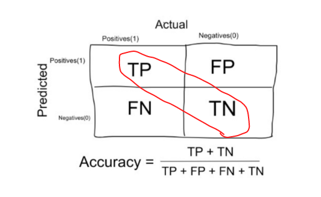

- **Acurácia balanceada** (*balanced accuracy*): Média do número de classificações corretas sobre o total de classificações para cada categoria separadamente. Essa medida é preferível quando as classes do desfecho não são balanceadas (ex: número de controles é muito maior que o de casos).
- **Precisão ou valor preditivo positivo** (*Precision*): Número de positivos verdadeiros sobre o total de positivos.

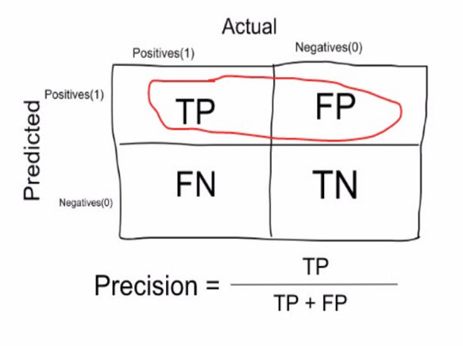

- **Revocação / Sensibilidade** (*Recall ou Sensitivity*): Número de positivos verdadeiros sobre o total de verdadeiros. Também chamada de taxa de positivos verdadeiros.

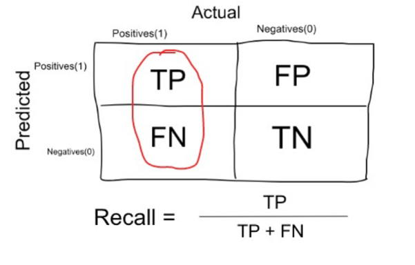

- **Especificidade** (*Specificity*): Número de negativos verdadeiros sobre o total de negativos. Também chamada de taxa de negativos verdadeiros.

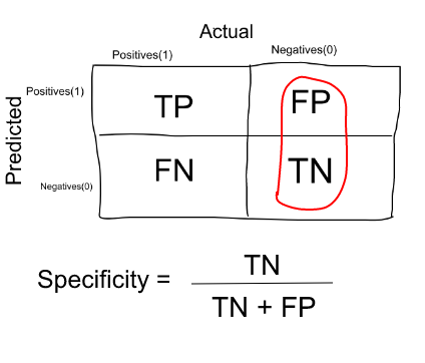

- **Escore F1** (*F1-score*): Média harmônica entre precisão e recall. Valores próximos de 1 indicam que o modelo de classificação é bom.
- **Área sob a curva ROC** (*Area under receiver operating characteristic curve*): Área sob a curva da relação entre `1-especificidade` e `sensibilidade`. Valores próximos de 1 indicam que o modelo de classificação é bom.

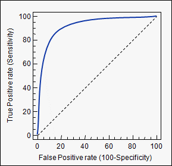

```r
# Definindo um objeto com todas as medidas de avaliação de desempenho mencionadas. Para o pacote mlr, é necessário criar uma lista
medidas_desemp <- list(acc, bac,ppv, tpr, f1, auc)
```

### Métodos de aprendizagem

- `class.task.treino.rs190962`: tarefa para predizer desfecho usando dados apenas do SNP rs190962;
- `class.task.teste.rs190962`: tarefa para avaliar predição usando apenas o SNP rs190962;
- `class.task.treino.todos`: tarefa para predizer desfecho usando todos os SNPs;
- `class.task.teste.todos`: tarefa para avaliar predição usando todos os SNPs.

A última definição que precisamos fazer são os métodos de aprendizagem. Estes se referem aos nomes dos diferentes modelos que podem ser utilizados para uma tarefa específica (ex: regressão logística, *support vector machines*, *random forests*, etc.) A seguir, vamos discutir brevemente diferentes métodos de aprendizagem e defini-los.

## Regressão logística

O objetivo da regressão logística em aprendizagem de máquina é ajustar um modelo de predição, de maneira a avaliar a probabilidade de um determinado valor de variáveis independentes pertencer a uma das categorias do desfecho. Em nosso exemplo, estamos calculando a probabilidade de pertencer à categoria `Caso` dado um determinado valor de cada genótipo (`0`, `1` ou `2`).

O resultado de uma regressão logística, por ser uma probabilidade, é um valor que varia entre 0 e 1. Por ser um modelo de classificação, o objetivo é utilizar a probabilidade resultante do modelo de regressão logística para informar a categoria do desfecho que uma observação pertence. De maneira padrão, caso a probabilidade de uma determinada observação de pertencer à uma categoria do desfecho seja > 0.5, esta observação é classificada nesta categoria. No fim, a categoria predita de cada observação é comparada com a categoria real, e as diferentes medidas de desempenho são calculadas, indicando se o modelo de classificação é bom ou não.

Vamos fazer um exemplo simples de regressão logística usando a tarefa `class.task.treino.rs190962`. Primeiramente, vamos definir o método de aprendizagem:

```r
# Definir método de aprendizagem da Regressão Logística, e definir que o resultado da predição é do tipo "prob"", ou seja, para cada observação, calcular a probabilidade de ser "Caso" dado o(s) genótipo(s) para o(s) SNP(s) estudados
metodo.RL <- makeLearner("classif.logreg", predict.type = "prob")
```

Em seguida, vamos treinar o método que definimos (`metodo.RL`) na tarefa `class.task.treino.rs190962`, e olhar alguns resultados nos dados de treino, inclusive o desempenho do modelo nos dados de treino.

```r
# Treinar o modelo
modelo.RL.treino.rs190962 <- train(learner = metodo.RL, task = class.task.treino.rs190962)

# Observar o modelo que foi definido
getLearnerModel(modelo.RL.treino.rs190962)

# Observar os coeficientes do modelo
summary(getLearnerModel(modelo.RL.treino.rs190962))

# Fazer predições nos dados de treino
pred.modelo.RL.rs190962.treino <- predict(modelo.RL.treino.rs190962, task = class.task.treino.rs190962)

# Calcular a matriz de confusão para observar quantas observações foram classificadas corretamente
calculateConfusionMatrix(pred.modelo.RL.rs190962.treino)

# Apenas olhando a matriz de confusão, parece que várias observações foram classificadas erroneamente. Vamos agora calcular todas as medidas de desempenho e avaliar este modelo nos dados de teste.
performance(pred.modelo.RL.rs190962.treino, measures = medidas_desemp)

# Vamos construir a curva ROC desta classificação (fpr e tpr são 1-especificidade e sensibilidade, respectivamente)
roc_curve.pred.modelo.RL.rs190962.treino <- generateThreshVsPerfData(pred.modelo.RL.rs190962.treino, measures = list(fpr, tpr))
plotROCCurves(roc_curve.pred.modelo.RL.rs190962.treino)
```

[output not shown]

```r
# Treinar o modelo com todos os SNPs. Note que o método é o mesmo (metodo.RL)
modelo.RL.treino.todos <- train(learner = metodo.RL, task = class.task.treino.todos)

# Observar o modelo que foi definido
getLearnerModel(modelo.RL.treino.todos)

# Observar os coeficientes do modelo
summary(getLearnerModel(modelo.RL.treino.todos))

# Usar o modelo calculado para fazer predições nos dados de treino.
pred.modelo.RL.todos.treino <- predict(modelo.RL.treino.todos, task = class.task.treino.todos)

# Calcule matriz de confusão
calculateConfusionMatrix(pred.modelo.RL.todos.treino)

# Avalie desempenho do novo modelo nos dados de treino
performance(pred.modelo.RL.todos.treino, measures = medidas_desemp)

# Vamos construir a curva ROC desta classificação
roc_curve.pred.modelo.RL.todos.treino <- generateThreshVsPerfData(pred.modelo.RL.todos.treino, measures = list(fpr, tpr))
plotROCCurves(roc_curve.pred.modelo.RL.todos.treino)
```

[output not shown]

Ao incluir mais variáveis, nosso novo modelo parece ser um pouco melhor, com acurácia de 58.8%, e AUC de 0.627. No entando, não podemos dizer que este é um modelo muito bom. Além disso, estamos avaliando o desempenho dos modelos nos mesmos dados que foram utilizados para o treino. Idealmente, precisamos avaliar estes modelos nos dados de teste. Vamos fazer isso agora e verificar se estas predições, mesmo que deficientes, são consistentes em dados que não foram utilizados no treino.

```r
# Usar os modelos calculados para fazer predições nos dados de teste
pred.modelo.RL.rs190962.teste <- predict(modelo.RL.treino.rs190962, task = class.task.teste.rs190962)
pred.modelo.RL.todos.teste <- predict(modelo.RL.treino.todos, task = class.task.teste.todos)

# Calcule matrizes de confusão
calculateConfusionMatrix(pred.modelo.RL.rs190962.teste)
calculateConfusionMatrix(pred.modelo.RL.todos.teste)

# Avalie desempenho dos dois modelos nos dados de teste
performance(pred.modelo.RL.rs190962.teste, measures = medidas_desemp)
roc_curve.pred.modelo.RL.rs190962.teste <- generateThreshVsPerfData(pred.modelo.RL.rs190962.teste, measures = list(fpr, tpr))
plotROCCurves(roc_curve.pred.modelo.RL.rs190962.teste)

performance(pred.modelo.RL.todos.teste, measures = medidas_desemp)
roc_curve.pred.modelo.RL.todos.teste <- generateThreshVsPerfData(pred.modelo.RL.todos.teste, measures = list(fpr, tpr))
plotROCCurves(roc_curve.pred.modelo.RL.todos.teste)
```

[output not shown]

**De acordo os resultados das medidas de desempenho nos dados de teste, como você avaliaria estes modelos?**

Infelizmente, parece que a regressão logística não um modelo muito adequado para classificar Status a partir de dados de genotipagem de SNPs (pelo menos nestes dados simulados). Porém, como todo experimento computacional em aprendizagem de máquina, é possível testarmos outros métodos.